# Bring your own data

Day 4 - Introduction to Data Analysis with R

Selina Baldauf

Freie Universität Berlin - Theoretical Ecology

October 17, 2026

## Organization

**Schedule of today**

- **Now - 14.30**: Work on the data set(s)
  - Take break(s) as best fits your needs
- **14.30 - 15**: Short feedback round
  - What did you find out about your data set? Plots, summaries, …
  - Which methods did you use?
  - Did you learn something new?
  - Was there something you struggled with?
  - …
- **15-16**: Feedback, conclusion

## Data set 1: What makes a good wine?

see [here](https://selinazitrone.github.io/intro-r-data-analysis/byod/wine.html)

[figure not shown]

Frederik Vandaele - originally posted to Flickr as Château Pétrus, CC BY 2.0, https://commons.wikimedia.org/w/index.php?curid=5145286

## Data set 2: Paralympic games from 1980-2016

see [here](https://selinazitrone.github.io/intro-r-data-analysis/byod/olympics.html)

## Data set 3: Ice cover and temperature

see [here](https://selinazitrone.github.io/intro-r-data-analysis/byod/ice_cover.html)

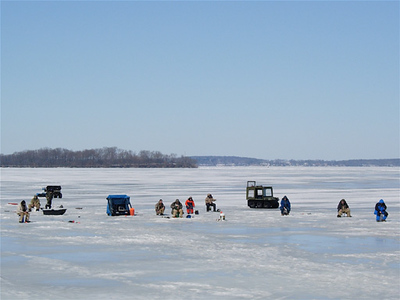

Image by LTER under CC BY-SA 4.0

Source ice data: [Magnuson, J.J., S.R. Carpenter, and E.H. Stanley. 2021.](https://doi.org/10.6073/pasta/ab31f2489ee436beb73fc8f1d0213d97) North Temperate Lakes LTER: Ice Duration - Madison Lakes Area 1853 - current ver 35. Environmental Data Initiative.

Source temperature data: [Anderson, L. and D. Robertson. 2020.](https://doi.org/10.6073/pasta/e3ff85971d817e9898bb8a83fb4c3a8b) Madison Wisconsin Daily Meteorological Data 1869 - current ver 32. Environmental Data Initiative.

## Data set 4: RNAseq data

see [here](https://selinazitrone.github.io/intro-r-data-analysis/byod/dnaseq.html)

## New methods: Read multiple files at once

- If you have multiple files with data you can
  - Read them all in at the same time
  - Combine them into one tibble

## New methods: Correlation plots

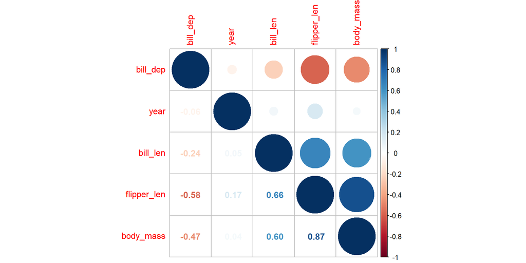

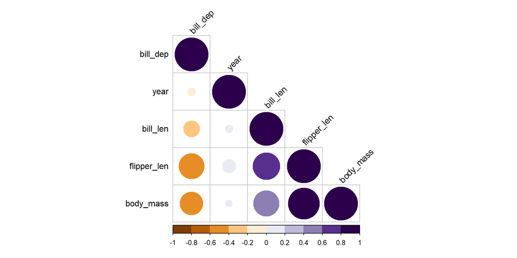

## New methods: PCA

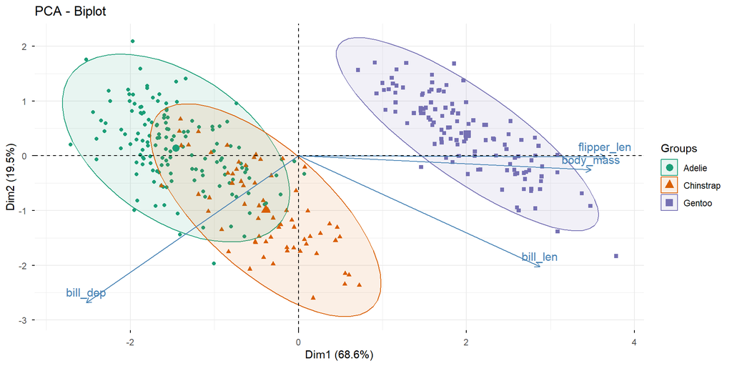

## How it works

- Start working on your data set or select one of mine
- You can also do other things like
  - Look at the example scripts to learn new techniques
  - Try AI tools, Quarto, Positron, …
- If you are stuck
  - Ask Google or AI tools
  - Aks me: Meeting or write me on Webex

# Now you

Working with real data

- **Work** on your data set
- **Take breaks** as you need and **be back at 2.30 p.m.**

## Sharing

In **1-2 mins**:

- What was the highlight of your analysis?
  - Your favorite plot
  - Some cool code
  - A problem that you finally solved
  - Something new you learned
- What was difficult?
- If you want: Share a screenshot in the chat or share your screen

## Feedback

Please take 10 mins to complete the feedback survey for the Graduate center (don’t use Internet Explorer)

https://votingo.cedis.fu-berlin.de/PCNLP3

## Conclusion

[figure not shown]

We learned a lot of stuff!

## Conclusion

#### How to continue from here?

- Learning by doing!
- Have a look at some [online ressoures](https://selinazitrone.github.io/intro-r-data-analysis/online_resources.html)
- [FU statistical consulting](http://www.stat.fu-berlin.de/en/dienstleistungen/index.html) for questions regarding statistical methods
- [R Consulting by me](https://www.bcp.fu-berlin.de/en/graduiertenzentrum/promovierende/beratung/index.html)
- [Tools and Tips lecture](https://selinazitrone.github.io/tools_and_tips/)

[figure not shown]

Artwork by [Allison Horst](https://twitter.com/allison_horst)

# The End

Thanks a lot for participating!

[figure not shown]

Artwork by [Allison Horst](https://twitter.com/allison_horst)